# Exercício 2 da Aula 11 - Mapeamento de Múltiplos Intervalos

#### 1.4.3.1 Resultado do MIM - fenótipo fl (phe 1)

[output not shown]

Também e possível observar o gráfico do MIM contendo os QTLs para o caráter **fl** e suas respectivas posições no genoma.

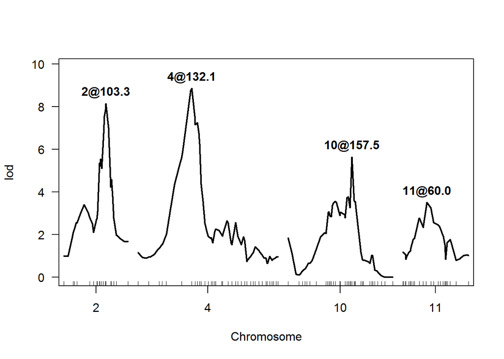

```r
plotLodProfile(mimulus_mim)
```

## 1.5 Comentários finais sobre CIM e MIM

CIM - Utiliza um método de regressão com cofatores (sendo os marcadores usados como cofatores). O uso de cofatores nesse método permite explicar parte da variação genética e minimizar erros, aumentando a precisão da análise.

MIM - Modelo que considera simultaneamente múltiplos QTL’s. Não utiliza marcadores como cofatores, mas sim os próprios QTLs existentes. Os principais procedimentos do mapeamento MIM são seleção e comparação de modelos. Combina alta precisão e poder estatístico. Permite a inclusão de epistasia (interação entre locos). Permite o estudo da arquitetura genética dos caracteres quantitativos. Permite estimar o número, posição, efeitos e interação entre QTL’s.

Em comparação, os dois métodos se mostraram bom no exemplo estudado. Para a característica **pa** (phe 6) tanto pelo CIM como MIM foi encontrado apenas um QTL, sendo o mesmo QTL pelas duas metodologias. Já para a característica **fl** (phe 1) no CIM foi encontrado apenas um QTL e no MIM foram encontrados mais três QTLs (totalizando quatro QTLs) e um interação entre QTLs, o que pode evidenciar um maior poder de detecção de QTLs do método MIM.